# Professional Profile — Alexandre

Professional Matching Report

Atlas Research Team

2022-12-13

# Introduction

Hello, Alexandre! Welcome to your professional matching report! In this document, you’ll find solidly researched information on your compatibility with 873 different career paths.  
Our state-of-the-art psychometric models and questionnaires were developed using publicly available data from the [Bureau of Labor Statistics (BLS)](https://www.bls.gov/) and the [Occupational Information Network (ONET)](https://www.onetonline.org/). This database consists in a set of 161 job characteristics, such as entry level of education, required skills, abilities and other competencies (rated from 0 to 1), as well as typical job activities, job hazards, and so on.  
One of our goals at Atlas Research is to determine the career that best fits your professional profile. Therefore, we assess your most important competencies and job preferences, and compare these with the 873 occupations we’ve gathered from the BLS and ONET. Then, we arrange your professional matches best to worst and estimate a compatibility score as a percentage, indicating your similarity to each occupation.  
Don’t forget to register at https://www.go2atlas.com/ to view more detailed reports and gain access to our Mentorship Program. We hope you obtain value from this report. Have a great day!

# Professional Compatibility Overview

## Ranking

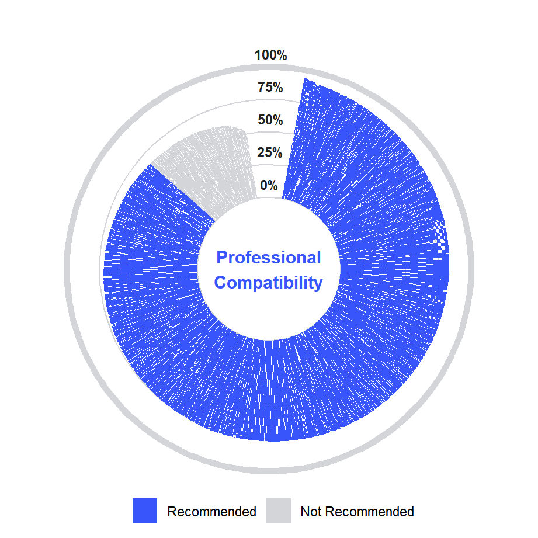

Professional Compatibility Ranking

Your Top 7 and Bottom 3 Career Matches

| Rank | Occupation | Wage | Compatibility |
| --- | --- | --- | --- |
| 1 | Social Work Teachers, Postsecondary | $71,010.00 | 94.05% |
| 2 | Credit Authorizers, Checkers, and Clerks | $44,710.00 | 93.99% |
| 3 | Marriage and Family Therapists | $49,880.00 | 93.34% |
| 4 | Market Research Analysts and Marketing Specialists | $63,920.00 | 92.96% |
| 5 | Purchasing Managers | $127,150.00 | 92.63% |
| 6 | Judicial Law Clerks | $50,750.00 | 92.60% |
| 7 | Title Examiners, Abstractors, and Searchers | $47,310.00 | 92.51% |
| 871 | Security Guards | $31,470.00 | 52.66% |
| 872 | Hydroelectric Plant Technicians | $80,850.00 | 51.20% |
| 873 | Loading and Moving Machine Operators, Underground Mining | $57,900.00 | 47.33% |

Considering this, firstly we note that your best match is ``Social Work Teachers, Postsecondary”, with 94.05% compatibility; and the worst is ``Loading and Moving Machine Operators, Underground Mining”, with 47.33%. The median match is ``Computer Numerically Controlled Tool Programmers”, with 77.32% compatibility, below which lies 50% of careers. Thus, it is apparent that the scope of your recommended activities is extremely wide, covering around 766 occupations.

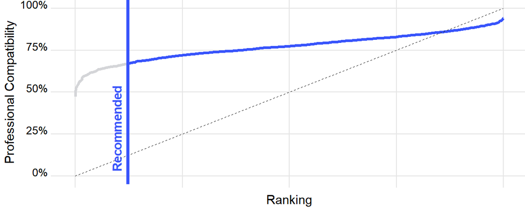

Professional Compatibility Curve

Now, one important thing to comment on is the shape of your professional compatibility curve. For the slope of the curve is an indirect measure of how spread apart is your professional profile. If the curve is flat, then all values are identical. But, in contrast, as the angle of the line increases to 45 degrees (as in the dashed black line), all observations become evenly spaced out and well distributed. And since the distribution in question concerns the viability of different types of employment options, the slope of the professional compatibility curve, in conjunction with the range of recommended occupations, is a strong indicator of the broadness of your professional profile.

## Distribution

It is straightforward to understand the above-mentioned distribution of viable careers by looking at a histogram of professional compatibility scores (Figure 3). A histogram is a data visualization tool which enables us to clearly see the dispersion of a given variable. It works by segmenting data into a desired number of intervals called bins, denoted by the columns on the graph. The height of each column is proportional to the frequency of data points within its bin. Hence, the tallest columns represent the most frequent intervals or classes of data, and as the columns decrease in height, so too the data points in a bin decrease in frequency.

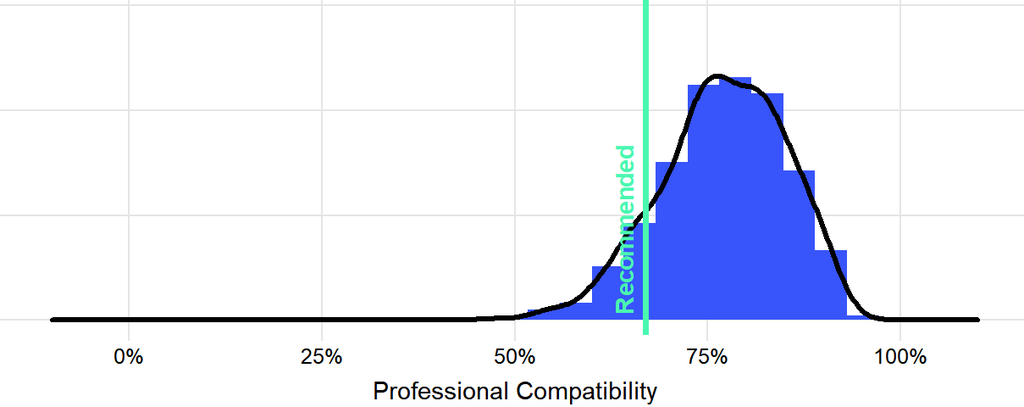

Professional Compatibility Distribution

Figure 3 also displays an overlaid density curve of compatibility scores. A density plot is analogous to a histogram, and likewise it is used to evaluate a variables’s dispersion and centrality. However, where histogram bins are discrete in nature (they are *fixed* intervals of numeric data), densities are smooth, continuous and not limited by discrete bins. The vertical axis is omitted for simplicity’s sake, as densities are dimensionless and not interpretable in themselves.  
At any rate, it is now even more evident how your professional profile is distributed, as the outline of Figure 3 makes visible several key aspects of your overall employability. For instance, higher variance of similarity scores makes the histogram and density to be shorter in height, but horizontally larger. Less varied, or specialized, profiles, on the other hand, produce slimmer and taller histograms and densities. The centrality of the distribution is very important as well: if compatibility scores concentrate at the lower end of the scale, then most occupations are a poor match and viable career paths will be limited; but if the distribution is centered toward the right end of the scale, then the opposite is true. It bears mentioning that although graphically the 50% mark appears to be the ``middle” of the scale, this analysis is related to the distribution of *recommended* occupations, which is itself centered further to the right.  
Statistically, we can assess how dispersed is the compatibility curve by calculating the standard deviation of your compatibility scores. In addition, the skewness and mode of the curve tell us if your profile is restricted to a few niche occupations or if it is less defined. By doing these calculations, we find you have exceptionally left-skewed matching percentages across all occupations. This means that, after accounting for the variance of compatibility scores, the broadness of your professional profile is enormous, and you should fare essentially the same in most career paths, all else being equal.

# Brief Compatibility Analysis

We now move to an analysis of your top and bottom career matches. However, before this can be done, we must clarify some terminology.

## Categories and Factors

Our psychometric questionnaire for professional profiling is based upon three different categories of job-related competencies and preferences: “Skills”, “Abilities”, and “Fields of Knowledge”. By this we mean that any item in the questionnaire is associated with one of three ``very general types” of attributes, or categories.  
The categories, in turn, are divided into individual *factors*. In psychometrics, factor analysis is a technique to group variables according to how they correlate to one another. These groups of variables are called factors, and all items in our questionnaire have been empirically assigned to nine factors. Thus, categories are divided into factors, which are themselves divided into items. This is how the Atlas Professional Profiling Questionnaire is organized.  
Since explaining the intricate statistical procedures employed in the construction of our psychometric models is not the main focus of this brief report, we limit ourselves to listing the categories of analysis, with their respective factors. Firstly, the ``Skills” category is composed of two factors: “Discernment”, and “Technical Skills”. Secondly, the ``Abilities” category splits into: “Perception”, “Dexterity”, and “Intelligence”. And finally, the category ``Fields of Knowledge” contains four factors: “Health Science”, “Building”, “Business”, and “Arts & Humanities”. These are the categories and factors covered by the thirty-three items in the model.

## Your Best and Worst Matches

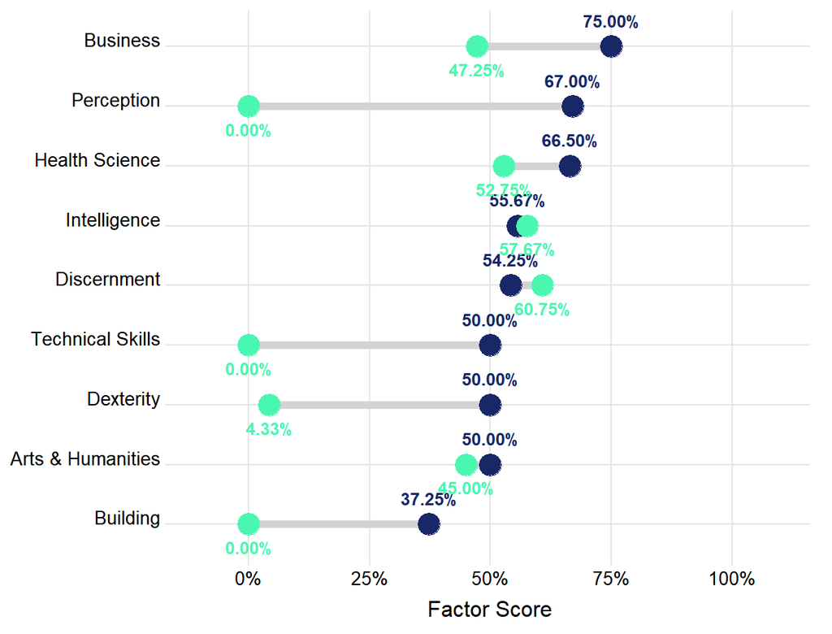

Your Best Career Match — Social Work Teachers, Postsecondary

Figure 4 gives us a glimpse of your professional compatibility with ``Social Work Teachers, Postsecondary”, your best career match. Here, we immediately see that you’re most similar with respect to the “Intelligence” factor, and most dissimilar with respect to “Perception”, the differences comprised within 2 and 67 percentage points. We also observe that you’re underqualified for exercizing this occupation in two factors (viz. “Discernment”, and “Intelligence”), and overqualified in “Technical Skills”, “Perception”, “Dexterity”, and so on. Lastly, your three biggest strengths are “Business”, “Health Science”, and “Perception”, while those of ``Social Work Teachers, Postsecondary” are “Discernment”, “Health Science”, and “Intelligence”.

Finally, the figure below features an analysis of your least compatible occupation, ``Loading and Moving Machine Operators, Underground Mining”:

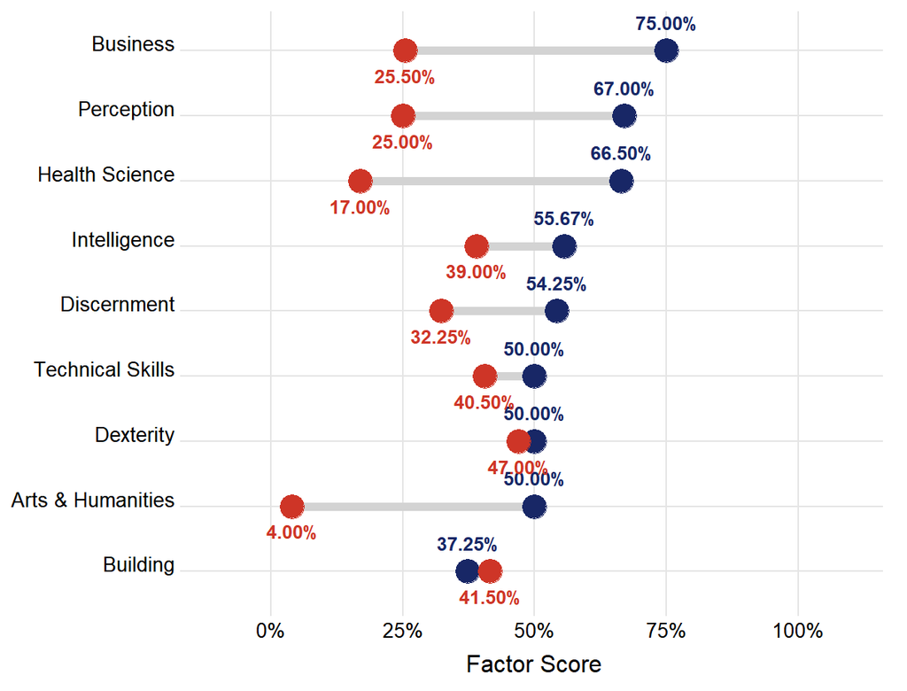

Your Worst Career Match — Loading And Moving Machine Operators, Underground Mining

Again, it is immediate to notice that the “Dexterity” factor is the highest point of similarity, while the lowest are “Health Science”, and “Business”. In this case, the differences range from 3 to 49.5 percentage points. In terms of your current capacity to exercize this profession, we assess you to be underqualified in the “Building” factor, and overqualified in the rest of them. The three biggest strengths of ``Loading and Moving Machine Operators, Underground Mining” are “Building”, “Dexterity”, and “Technical Skills”, which have nothing in common with yours.

# Finishing Remarks

In this report, we went over your results in the Atlas Professional Profiling Questionnaire. We began by examining a ranking of occupations, based on similarity of job-related attributes, and underscoring the 766 career paths that constitute your extremely wide scope of recommended occupations. After that, we looked at the professional compatibility curve and its shape, also indicative of your degree of specialization. Investigating further the distribution of compatibility scores, we found that you have an exceptionally broad or multidisciplinary professional profile, meaning you will almost definitely benefit from investing in more than a single career path, and specialization may actually hinder your ability to exercize all of your different competencies. At last, we briefly analyzed your best and worst career matches, respectively: ``Social Work Teachers, Postsecondary”, and ``Loading and Moving Machine Operators, Underground Mining”. Concerning the first of these, you seem to be mostly overqualified. And as regards the second, mostly overqualified as well.  
Having considered all of this, we now conclude your career matching report. Again, this is but a brief overview of your professional profile, and you can access much more detailed, in-depth reports by registering at https://www.go2atlas.com/ today. There, we offer a suite of varied career support programs, including highly qualified curated mentorships, career roadmaps, and more. Thank you for your time, Alexandre. The Atlas Team wishes you well. May you find your best professional future ahead!